# 🍫 Chocolate Bar Ratings Analysis

[figure not shown]

[figure not shown]

[figure not shown]

[figure not shown]

[figure not shown]

# About

### 📌 Project Information

#### 📚 Course Details

| **Course Code** | MIS029 |
| --- | --- |
| **Course Name** | Data Visualization |
| **Project Type** | Final Project Dashboard |

#### 👤 Student Information

| **Name & Surname** | Mert Efe Kurt |
| --- | --- |
| **Student Number** | 2307071061 |
| **Submission Date** | 15 January 2026 |

#### 📊 Dataset Overview

| **Dataset** | Chocolate Bar Ratings |
| --- | --- |
| **Source** | TidyTuesday 2022-01-18 |
| **Observations** | 2,530 |
| **Variables** | 10 original + 3 derived |
| **Period** | 2006 - 2021 |

### 📖 About This Dataset

**Expert ratings of over 2,500 chocolate bars** from around the world, compiled by the **Manhattan Chocolate Society** via [Flavors of Cacao](http://flavorsofcacao.com/).

🌍 **67** countries | 🏭 **580** manufacturers | 🌱 **62** bean origins

**Rating Scale:**

| Score | Category |
| --- | --- |
| 4.0 - 5.0 | 🏆 Outstanding |
| 3.5 - 3.9 | ⭐ Highly Recommended |
| 3.0 - 3.49 | ✓ Recommended |
| 2.5 - 2.99 | ⚠️ Disappointing |
| 1.0 - 2.49 | ✗ Unpleasant |

### 📋 Variable Names and Types

| # | Variable | Type | Description |
| --- | --- | --- | --- |
| 1 | ref | Numeric | Unique reference ID |
| 2 | company_manufacturer | Character | Manufacturer name |
| 3 | company_location | Character | Manufacturer country |
| 4 | review_date | Numeric | Review year |
| 5 | country_of_bean_origin | Character | Bean origin country |
| 6 | specific_bean_origin_or_bar_name | Character | Bean variety/bar name |
| 7 | cocoa_percent | Character | Cocoa % (text) |
| 8 | ingredients | Character | Ingredient codes |
| 9 | most_memorable_characteristics | Character | Flavor notes |
| 10 | rating | Numeric | Rating (1-5) |
| 11 | cocoa_percent_num | Numeric | Cocoa % [Derived] |
| 12 | num_ingredients | Numeric | Ingredient count [Derived] |
| 13 | rating_category | Factor | Rating label [Derived] |

### 🔍 Data Structure Preview

| Metric | Value |
| --- | --- |
| Rows (Observations) | 2,530 |
| Columns (Variables) | 13 |
| Memory Size | 611.5 Kb |
| Complete Cases | 2,443 |
| Missing Values | 174 |

# Summary

### 📊 Summary Statistics for Numeric Variables

| Variable | N | Mean | Median | SD | Min | Max |
| --- | --- | --- | --- | --- | --- | --- |
| Cocoa Percentage (%) | 2530 | 71.64 | 70.00 | 5.62 | 42 | 100 |
| Number of Ingredients | 2443 | 3.04 | 3.00 | 0.91 | 1 | 6 |
| Rating Score | 2530 | 3.20 | 3.25 | 0.45 | 1 | 4 |
| Review Year | 2530 | 2014.37 | 2015.00 | 3.97 | 2006 | 2021 |

### 📍 Frequency Table: Top Manufacturing Countries

| Country | Count | Pct | Cum.Pct |
| --- | --- | --- | --- |
| U.S.A. | 1136 | 44.9 | 44.9 |
| Canada | 177 | 7.0 | 51.9 |
| France | 176 | 7.0 | 58.9 |
| U.K. | 133 | 5.3 | 64.2 |
| Italy | 78 | 3.1 | 67.3 |
| Belgium | 63 | 2.5 | 69.8 |
| Ecuador | 58 | 2.3 | 72.1 |
| Australia | 53 | 2.1 | 74.2 |
| Switzerland | 44 | 1.7 | 75.9 |
| Germany | 42 | 1.7 | 77.6 |
| Spain | 36 | 1.4 | 79.0 |
| Denmark | 31 | 1.2 | 80.2 |

### 🌱 Frequency Table: Top Bean Origin Countries

| Bean Origin | Count | Pct | Cum.Pct |
| --- | --- | --- | --- |
| Venezuela | 253 | 10.0 | 10.0 |
| Peru | 244 | 9.6 | 19.6 |
| Dominican Republic | 226 | 8.9 | 28.5 |
| Ecuador | 219 | 8.7 | 37.2 |
| Madagascar | 177 | 7.0 | 44.2 |
| Blend | 156 | 6.2 | 50.4 |
| Nicaragua | 100 | 4.0 | 54.4 |
| Bolivia | 80 | 3.2 | 57.6 |
| Colombia | 79 | 3.1 | 60.7 |
| Tanzania | 79 | 3.1 | 63.8 |
| Brazil | 78 | 3.1 | 66.9 |
| Belize | 76 | 3.0 | 69.9 |

### ⭐ Frequency Table: Rating Categories

| Category | Count | Pct | Cum.Pct |
| --- | --- | --- | --- |
| Outstanding | 112 | 4.4 | 4.4 |
| Highly Recommended | 865 | 34.2 | 38.6 |
| Recommended | 987 | 39.0 | 77.6 |
| Disappointing | 499 | 19.7 | 97.3 |
| Unpleasant | 67 | 2.6 | 99.9 |

### 🔢 Quick Stats

2,530

# Histogram

### 📊 Histogram: Distribution of Expert Chocolate Ratings

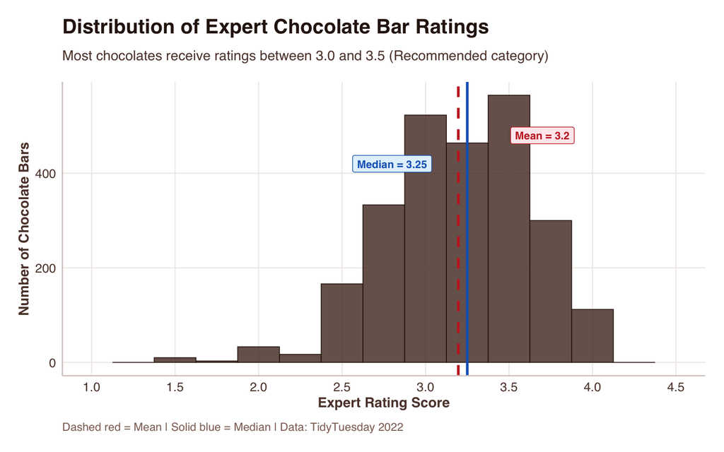

### 🍫 Cocoa Percentage Distribution

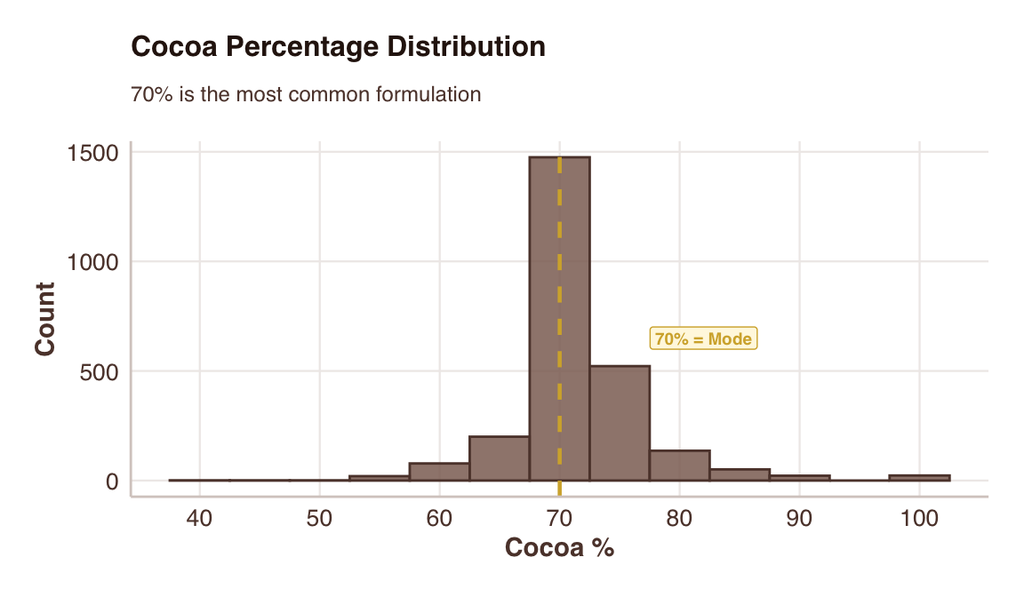

### 📈 Key Statistics

| Statistic | Rating | Cocoa % |
| --- | --- | --- |
| **Mean** | 3.2 | 71.6% |
| **Median** | 3.25 | 70% |
| **Std Dev** | 0.45 | 5.6% |
| **Range** | 1 - 4 | 42 - 100% |

# Boxplot

### 📦 Multiple Boxplot: Rating Distribution by Manufacturing Country

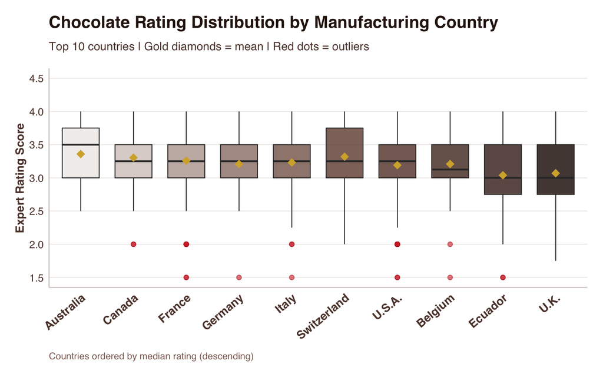

### 📊 Rating by Cocoa Range

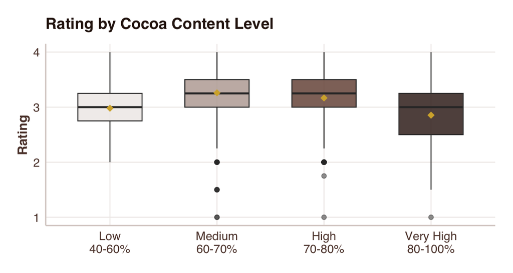

### 📋 Country Statistics

[output not shown]

# Scatterplot

### 🔵 Scatterplot: Cocoa Percentage vs Rating by Bean Origin Region

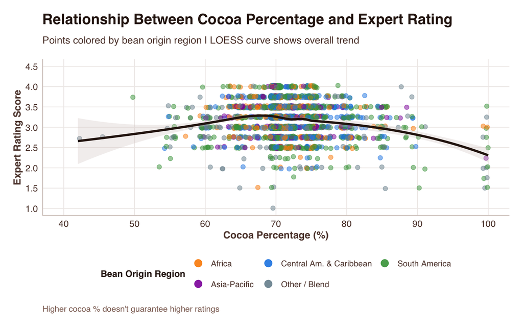

### 📝 Scatterplot Interpretation

This scatterplot explores the relationship between **cocoa percentage** and **expert ratings**. The LOESS curve reveals that ratings **peak around 65-75% cocoa**, then decline at higher percentages. The weak negative correlation (**r = -0.147**) indicates cocoa content alone doesn’t determine quality.

### 📊 Correlation Analysis

r = -0.147

⚠️ **Weak Negative Correlation**

Cocoa % explains only 2.2% of rating variance

### 🌍 Statistics by Bean Region

| Region | Count | Avg Rating | Avg Cocoa |
| --- | --- | --- | --- |
| Central Am. & Caribbean | 683 | 3.22 | 72% |
| Africa | 357 | 3.21 | 71% |
| Asia-Pacific | 231 | 3.21 | 71% |
| South America | 953 | 3.20 | 72% |
| Other / Blend | 306 | 3.08 | 71% |

### 💡 Key Findings

**Insights:**

- **Weak Correlation** (r = -0.147): Cocoa % has minimal impact
- **Sweet Spot**: 65-75% cocoa achieves highest scores
- **Diminishing Returns**: Very dark chocolate (>85%) scores lower
- **Regional Consistency**: All bean regions show similar patterns

# Interactive

### 🖱️ Interactive Visualization: Explore Each Chocolate Bar (ggplotly)

[interactive chart not shown]

### 📝 Interactive Features

**Native Plotly** with **WebGL** for optimal performance. Stratified sample (40% per category). **Hover** for details, use toolbar to **zoom/pan/download**.

### 📖 How to Use This Chart

**Hover** over points to see: Manufacturer name, location, bean origin, cocoa %, rating & category.

**Toolbar Options:** Download PNG, Zoom in/out, Pan, Reset view.

**Color Legend:**

| Color | Category |
| --- | --- |
| 🟢 Green | Outstanding / Highly Recommended |
| 🟡 Orange | Recommended |
| 🔴 Red | Disappointing / Unpleasant |

### ⭐ Rating Distribution

[interactive chart not shown]

# Data

### 🔍 Complete Dataset Explorer

| Manufacturer | Location | Year | Bean Origin | Bar Name | Cocoa | Rating | Category | Flavors |
| --- | --- | --- | --- | --- | --- | --- | --- | --- |
| 5150 | U.S.A. | 2019 | Tanzania | Kokoa Kamili, batch 1 | 76% | 3.25 | Recommended | rich cocoa, fatty, bready |
| 5150 | U.S.A. | 2019 | Dominican Republic | Zorzal, batch 1 | 76% | 3.5 | Highly Recommended | cocoa, vegetal, savory |
| 5150 | U.S.A. | 2019 | Madagascar | Bejofo Estate, batch 1 | 76% | 3.75 | Highly Recommended | cocoa, blackberry, full body |
| 5150 | U.S.A. | 2021 | Fiji | Matasawalevu, batch 1 | 68% | 3 | Recommended | chewy, off, rubbery |
| 5150 | U.S.A. | 2021 | Venezuela | Sur del Lago, batch 1 | 72% | 3 | Recommended | fatty, earthy, moss, nutty,chalky |
| 5150 | U.S.A. | 2021 | Uganda | Semuliki Forest, batch 1 | 80% | 3.25 | Recommended | mildly bitter, basic cocoa, fatty |
| 5150 | U.S.A. | 2021 | India | Anamalai, batch 1 | 68% | 3.5 | Highly Recommended | milk brownie, macadamia,chewy |
| A. Morin | France | 2012 | Bolivia | Bolivia | 70% | 3.5 | Highly Recommended | vegetal, nutty |
| A. Morin | France | 2012 | Peru | Peru | 63% | 3.75 | Highly Recommended | fruity, melon, roasty |
| A. Morin | France | 2013 | Panama | Panama | 70% | 2.75 | Disappointing | brief fruit note, earthy, nutty |

[output cut: 2520 more lines]

### ℹ️ Usage Tips

**How to use this table:**

- 🔍 **Filter:** Use the search boxes under each column header
- ↕️ **Sort:** Click on column headers to sort
- 📋 **Export:** Use Copy, CSV, or Excel buttons
- 📜 **Scroll:** Scroll within the table to see all 2530 records

**Column Guide:**

| Column | Description |
| --- | --- |
| Manufacturer | Company that made the chocolate |
| Location | Country where company is based |
| Year | When the review was conducted |
| Bean Origin | Where cocoa beans came from |
| Cocoa | Percentage of cocoa content |
| Rating | Expert score (1.0 - 5.0) |
| Category | Rating classification |
| Flavors | Tasting notes from experts |

# References

### 📚 Data Sources & Methodology

**Primary Data Source:**

📊 **TidyTuesday - Chocolate Bar Ratings (2022-01-18)**

| Attribute | Details |
| --- | --- |
| Repository | [github.com/rfordatascience/tidytuesday](https://github.com/rfordatascience/tidytuesday/tree/master/data/2022/2022-01-18) |
| Direct CSV | chocolate.csv |
| Records | 2,530 chocolate bar reviews |
| Time Span | 2006 - 2021 |
| Variables | 10 original columns |

**Original Data Provider:**

🍫 **Flavors of Cacao** - [flavorsofcacao.com](http://flavorsofcacao.com/chocolate_database.html)

- Compiled by: **Manhattan Chocolate Society**
- Rating methodology: Blind tasting by certified chocolate experts
- Scale: 1.0 (unpleasant) to 5.0 (elite/outstanding)

**Data Collection Method:**

Expert tasters evaluate chocolate bars on texture, flavor complexity, finish, and overall impression. Each bar is rated independently without brand knowledge.

### 📦 R Packages Used

| Package | Version | Purpose | Citation |
| --- | --- | --- | --- |
| flexdashboard | 0.6.2 | Dashboard framework & layout | Iannone et al. (2024) |
| tidyverse | 2.0.0 | Data wrangling (dplyr, tidyr, readr) | Wickham et al. (2019) |
| ggplot2 | 4.0.1 | Grammar of graphics visualizations | Wickham (2016) |
| plotly | 4.11.0 | Interactive charts with WebGL | Sievert (2020) |
| DT | 0.34.0 | Interactive searchable data tables | Xie et al. (2024) |
| knitr | 1.49 | Dynamic report generation | Xie (2024) |
| kableExtra | 1.4.0 | Advanced table formatting | Zhu (2024) |
| scales | 1.4.0 | Axis & label formatting | Wickham & Seidel (2022) |

### 🔗 Documentation & Tutorials

**Official Documentation:**

| Resource | URL | Purpose |
| --- | --- | --- |
| 📖 Flexdashboard | [pkgs.rstudio.com/flexdashboard](https://pkgs.rstudio.com/flexdashboard/) | Dashboard layouts & components |
| 📊 Plotly R | [plotly.com/r](https://plotly.com/r/) | Interactive visualizations |
| 🎨 ggplot2 | [ggplot2.tidyverse.org](https://ggplot2.tidyverse.org/) | Static graphics reference |
| 📋 DT Package | [rstudio.github.io/DT](https://rstudio.github.io/DT/) | DataTables integration |
| 📚 kableExtra | [haozhu233.github.io/kableExtra](https://haozhu233.github.io/kableExtra/) | Table styling |

**Books & Learning Resources:**

1. Wickham, H. & Grolemund, G. (2023). *R for Data Science* (2nd ed.). [r4ds.hadley.nz](https://r4ds.hadley.nz/)
2. Sievert, C. (2020). *Interactive Web-Based Data Visualization with R, plotly, and shiny*. Chapman & Hall/CRC. [plotly-r.com](https://plotly-r.com/)
3. Wilke, C. O. (2019). *Fundamentals of Data Visualization*. O’Reilly. [clauswilke.com/dataviz](https://clauswilke.com/dataviz/)
4. Healy, K. (2018). *Data Visualization: A Practical Introduction*. Princeton University Press.

**Course Materials:**

- MIS029 Data Visualization lecture notes
- Flexdashboard layout examples: pkgs.rstudio.com/flexdashboard/articles/layouts.html

### 🔄 Session Information

| Property | Value |
| --- | --- |
| R Version | 4.4.3 |
| Platform | aarch64-apple-darwin20 |
| Operating System | Darwin 25.1.0 |
| Locale | en_US.UTF-8 |
| Date Generated | 2026-01-15 19:09:27 |
| Timezone | Europe/Istanbul |

### 📋 Reproducibility & License

**To reproduce this analysis:**

```r
# 1. Install required packages
install.packages(c("flexdashboard", "tidyverse",
                   "plotly", "DT", "knitr",
                   "kableExtra", "scales"))

# 2. Render the dashboard
rmarkdown::render("MertEfeKurt_2307071061_Final.Rmd")
```

⚠️ **Requirements:**

- R version ≥ 4.0.0
- Internet connection (data fetched from GitHub)
- ~500 MB RAM for rendering

**Data License:** TidyTuesday data is released under CC0 1.0 Universal license.

**Dashboard Author:** Mert Efe Kurt (2307071061)

**Course:** MIS029 - Data Visualization

**Institution:** Final Project Submission

**Generated:** January 15, 2026 at 19:09

````r
---
title: "🍫 Chocolate Bar Ratings Analysis"
author: "Mert Efe Kurt | 2307071061"
output:
  flexdashboard::flex_dashboard:
    orientation: columns
    vertical_layout: scroll
    theme:
      version: 4
      bootswatch: cosmo
    navbar:
      - { title: "MIS029 Final Project", align: right }
    source_code: embed
---

```{css, echo=FALSE}
/* ===== PREMIUM CHOCOLATE THEME ===== */

/* Import elegant fonts */
@import url('https://fonts.googleapis.com/css2?family=Playfair+Display:wght@400;600;700&family=Source+Sans+Pro:wght@300;400;600&display=swap');

/* Root variables for consistent theming */
:root {
  --chocolate-dark: #2C1810;
  --chocolate-medium: #5D4037;
  --chocolate-light: #8D6E63;
  --chocolate-cream: #D7CCC8;
  --chocolate-milk: #EFEBE9;
  --gold-accent: #D4AF37;
  --gold-light: #F4E4BC;
  --success-green: #4CAF50;
  --warning-orange: #FF9800;
  --danger-red: #E53935;
}

/* Prevent horizontal overflow - CRITICAL */
html, body {
  overflow-x: hidden !important;
  max-width: 100% !important;
}

/* Global body styling */
body {
  font-family: 'Source Sans Pro', -apple-system, BlinkMacSystemFont, sans-serif;
  background: linear-gradient(135deg, #FAFAFA 0%, #F5F5F5 100%);
  color: var(--chocolate-dark);
  width: 100%;
  box-sizing: border-box;
}

/* Ensure all containers respect boundaries */
* {
  box-sizing: border-box;
}

/* Main container */
.container-fluid, .row {
  max-width: 100% !important;
  overflow-x: hidden !important;
}

/* Navbar styling */
.navbar {
  background: linear-gradient(135deg, var(--chocolate-dark) 0%, var(--chocolate-medium) 100%) !important;
  border-bottom: 3px solid var(--gold-accent) !important;
  box-shadow: 0 4px 20px rgba(44, 24, 16, 0.3);
}

.navbar-brand {
  font-family: 'Playfair Display', serif !important;
  font-weight: 700 !important;
  font-size: 1.5rem !important;
  color: var(--gold-light) !important;
  text-shadow: 1px 1px 2px rgba(0,0,0,0.3);
}

.navbar-nav > li > a {
  color: var(--chocolate-cream) !important;
  font-weight: 500;
  transition: all 0.3s ease;
}

.navbar-nav > li > a:hover {
  color: var(--gold-accent) !important;
  background: rgba(212, 175, 55, 0.15) !important;
}

.navbar-nav > .active > a {
  background: rgba(212, 175, 55, 0.25) !important;
  color: var(--gold-accent) !important;
  border-bottom: 2px solid var(--gold-accent);
}

/* Page titles */
.section.level3 > h3 {
  font-family: 'Playfair Display', serif;
  color: var(--chocolate-dark);
  font-weight: 600;
  border-bottom: 2px solid var(--gold-accent);
  padding-bottom: 8px;
  margin-bottom: 15px;
}

/* Chart containers */
.chart-wrapper {
  background: white;
  border-radius: 12px;
  box-shadow: 0 4px 15px rgba(44, 24, 16, 0.08);
  padding: 15px;
  transition: transform 0.3s ease, box-shadow 0.3s ease;
  max-width: 100% !important;
  overflow: hidden !important;
}

.chart-wrapper:hover {
  transform: translateY(-2px);
  box-shadow: 0 8px 25px rgba(44, 24, 16, 0.12);
}

/* Chart stage - allow vertical scroll when needed */
.chart-stage {
  max-width: 100% !important;
  overflow-x: hidden !important;
  overflow-y: auto !important;
  width: 100% !important;
}

/* Plotly and ggplot containers */
.plotly, .plotly-container, .html-widget {
  max-width: 100% !important;
  overflow: hidden !important;
}

/* Value boxes */
.value-box {
  border-radius: 12px !important;
  box-shadow: 0 4px 15px rgba(44, 24, 16, 0.15) !important;
  transition: transform 0.3s ease !important;
}

.value-box:hover {
  transform: scale(1.02);
}

.value-box .value {
  font-family: 'Playfair Display', serif !important;
  font-size: 2.2rem !important;
  font-weight: 700 !important;
}

.value-box .caption {
  font-family: 'Source Sans Pro', sans-serif !important;
  font-size: 0.85rem !important;
  font-weight: 500 !important;
  text-transform: uppercase;
  letter-spacing: 0.5px;
}

/* Tables - prevent horizontal scroll and fix backgrounds */
.dataTable {
  font-size: 0.9rem !important;
  max-width: 100% !important;
  width: 100% !important;
  table-layout: auto !important;
  background-color: white !important;
}

.dataTables_wrapper {
  max-width: 100% !important;
  overflow-x: hidden !important;
  background-color: white !important;
}

.dataTables_scroll {
  max-width: 100% !important;
  overflow-x: hidden !important;
  background-color: white !important;
}

/* Fix white space issue in Data table - CRITICAL */
.dataTables_scrollBody {
  background-color: white !important;
  overflow-y: auto !important;
}

.dataTables_scrollHead {
  background-color: white !important;
}

.dataTables_scroll {
  background-color: white !important;
}

table.dataTable {
  background-color: white !important;
}

table.dataTable tbody tr {
  background-color: white !important;
}

table.dataTable tbody tr:nth-child(odd) {
  background-color: #FAFAFA !important;
}

table.dataTable tbody tr:hover {
  background-color: var(--gold-light) !important;
}

/* Data page specific - fill container */
.chart-wrapper.html-fill-container {
  height: 100% !important;
  min-height: calc(100vh - 200px) !important;
}

/* Ensure DataTable fills its container */
.html-widget.html-fill-item {
  height: 100% !important;
  min-height: calc(100vh - 250px) !important;
}

.dataTable thead th {
  background: linear-gradient(135deg, var(--chocolate-dark), var(--chocolate-medium)) !important;
  color: white !important;
  font-weight: 600 !important;
  text-transform: uppercase;
  font-size: 0.8rem;
  letter-spacing: 0.5px;
  white-space: nowrap;
  overflow: hidden;
  text-overflow: ellipsis;
}

.dataTable tbody tr:hover {
  background-color: var(--gold-light) !important;
}

.dataTable tbody td {
  word-wrap: break-word;
  max-width: 200px;
  overflow: hidden;
  text-overflow: ellipsis;
}

/* Kable tables */
.table-striped > tbody > tr:nth-of-type(odd) {
  background-color: var(--chocolate-milk);
}

/* Custom card styling */
.info-card {
  background: linear-gradient(145deg, #FFFFFF 0%, var(--chocolate-milk) 100%);
  border-radius: 16px;
  padding: 25px;
  box-shadow: 0 8px 30px rgba(44, 24, 16, 0.1);
  border-left: 5px solid var(--gold-accent);
  margin-bottom: 20px;
}
````

````r
.premium-card {
  background: linear-gradient(135deg, var(--chocolate-dark) 0%, var(--chocolate-medium) 100%);
  color: white;
  border-radius: 16px;
  padding: 30px;
  box-shadow: 0 10px 40px rgba(44, 24, 16, 0.25);
}

.premium-card h4 {
  color: var(--gold-accent);
  font-family: 'Playfair Display', serif;
  margin-bottom: 15px;
}

/* Interpretation boxes - MUST BE VISIBLE */
.interpretation-box {
  background: linear-gradient(135deg, var(--chocolate-milk) 0%, #FFFFFF 100%);
  border-radius: 12px;
  padding: 18px 20px;
  margin-top: 20px;
  margin-bottom: 15px;
  border-left: 4px solid var(--gold-accent);
  font-size: 0.92rem;
  line-height: 1.65;
  box-shadow: 0 2px 8px rgba(44, 24, 16, 0.08);
  position: relative;
  z-index: 10;
}

/* Ensure chart wrappers don't overflow */
.chart-shim {
  overflow: hidden !important;
  max-width: 100% !important;
}

.section.level3 {
  overflow-x: hidden !important;
  overflow-y: auto !important;
  padding-bottom: 10px;
  max-width: 100% !important;
}

/* Column sections */
.section {
  max-width: 100% !important;
  overflow-x: hidden !important;
}

/* Flexdashboard columns */
.flexdashboard-column {
  max-width: 100% !important;
  overflow-x: hidden !important;
}

/* Stats highlight */
.stat-highlight {
  background: linear-gradient(135deg, var(--gold-light) 0%, #FFFFFF 100%);
  border-radius: 10px;
  padding: 15px 20px;
  text-align: center;
  box-shadow: 0 4px 15px rgba(212, 175, 55, 0.2);
}

.stat-highlight .number {
  font-family: 'Playfair Display', serif;
  font-size: 2.5rem;
  font-weight: 700;
  color: var(--chocolate-dark);
}

.stat-highlight .label {
  font-size: 0.85rem;
  color: var(--chocolate-light);
  text-transform: uppercase;
  letter-spacing: 1px;
}

/* Gauge styling */
.gauge-container {
  background: white;
  border-radius: 12px;
  padding: 20px;
  text-align: center;
}

/* Custom scrollbar */
::-webkit-scrollbar {
  width: 8px;
  height: 8px;
}

::-webkit-scrollbar-track {
  background: var(--chocolate-milk);
  border-radius: 4px;
}

::-webkit-scrollbar-thumb {
  background: var(--chocolate-light);
  border-radius: 4px;
}

::-webkit-scrollbar-thumb:hover {
  background: var(--chocolate-medium);
}

/* Animation for page load */
@keyframes fadeInUp {
  from {
    opacity: 0;
    transform: translateY(20px);
  }
  to {
    opacity: 1;
    transform: translateY(0);
  }
}

.chart-stage {
  animation: fadeInUp 0.6s ease-out;
}

/* Responsive adjustments */
@media (max-width: 768px) {
  .value-box .value {
    font-size: 1.8rem !important;
  }
  .navbar-brand {
    font-size: 1.2rem !important;
  }
  .dataTable {
    font-size: 0.75rem !important;
  }
  .premium-card, .info-card {
    padding: 15px !important;
  }
}

/* Kable tables - responsive */
table.kable-table, .table {
  max-width: 100% !important;
  width: 100% !important;
  table-layout: auto !important;
  font-size: 0.9rem !important;
}

table.kable-table td, table.kable-table th,
.table td, .table th {
  word-wrap: break-word;
  overflow: hidden;
  text-overflow: ellipsis;
  padding: 6px 8px !important;
}

/* Ensure variable table fits all content */
.table-condensed td, .table-condensed th {
  padding: 4px 6px !important;
  font-size: 11px !important;
  line-height: 1.3 !important;
}

/* Ensure all images and plots fit */
img, svg, canvas {
  max-width: 100% !important;
  height: auto !important;
}

/* Info cards and premium cards */
.info-card, .premium-card {
  max-width: 100% !important;
  word-wrap: break-word;
  overflow-wrap: break-word;
  overflow-y: auto !important;
}

/* Ensure tables in cards are compact */
.premium-card table, .info-card table {
  margin-bottom: 8px !important;
  font-size: 0.9rem !important;
}

.premium-card h4, .info-card h4 {
  margin-bottom: 8px !important;
  font-size: 1rem !important;
}

/* Value boxes container */
.value-box-container {
  max-width: 100% !important;
}

/* Ensure proper spacing and no overflow in sections */
.section {
  padding-left: 10px !important;
  padding-right: 10px !important;
}

/* Grid alignment - ensure columns fill properly */
.flexdashboard-page > .dashboard-row {
  display: flex !important;
  flex-wrap: nowrap !important;
  width: 100% !important;
}

.flexdashboard-page > .dashboard-row > .dashboard-column {
  display: flex !important;
  flex-direction: column !important;
}

/* Ensure panels stretch to fill available height */
.chart-wrapper {
  display: flex !important;
  flex-direction: column !important;
  flex: 1 1 auto !important;
}

.chart-stage {
  flex: 1 1 auto !important;
  display: flex !important;
  flex-direction: column !important;
}

/* No empty gaps between panels */
.section.level3 {
  margin-bottom: 0 !important;
  flex: 1 1 auto !important;
}

/* Fix any potential flexdashboard overflow */
.flexdashboard-content {
  max-width: 100% !important;
  overflow-x: hidden !important;
}
```

```{r setup, include=FALSE}
# ===== SETUP AND DATA LOADING =====
knitr::opts_chunk$set(
  echo = FALSE,
  message = FALSE,
  warning = FALSE,
  fig.retina = 2
)

# Load required libraries
library(flexdashboard)
library(tidyverse)
library(plotly)
library(DT)
library(scales)
library(knitr)
library(kableExtra)

# Load the chocolate dataset from TidyTuesday
chocolate <- read_csv(
  "https://raw.githubusercontent.com/rfordatascience/tidytuesday/master/data/2022/2022-01-18/chocolate.csv",
  show_col_types = FALSE
)

# ===== DATA PREPARATION =====
chocolate <- chocolate %>%
  mutate(
    # Convert cocoa_percent to numeric
    cocoa_percent_num = as.numeric(gsub("%", "", cocoa_percent)),
    # Extract number of ingredients
    num_ingredients = as.numeric(str_extract(ingredients, "^[0-9]")),
    # Create rating categories
    rating_category = case_when(
      rating >= 4 ~ "Outstanding",
      rating >= 3.5 ~ "Highly Recommended",
      rating >= 3 ~ "Recommended",
      rating >= 2.5 ~ "Disappointing",
      TRUE ~ "Unpleasant"
    ),
    rating_category = factor(rating_category, levels = c(
      "Outstanding", "Highly Recommended", "Recommended", "Disappointing", "Unpleasant"
    ))
  )
````

````r
# ===== SUMMARY STATISTICS =====
total_reviews <- nrow(chocolate)
avg_rating <- round(mean(chocolate$rating, na.rm = TRUE), 2)
num_countries <- n_distinct(chocolate$company_location)
num_manufacturers <- n_distinct(chocolate$company_manufacturer)
avg_cocoa <- round(mean(chocolate$cocoa_percent_num, na.rm = TRUE), 1)
num_origins <- n_distinct(chocolate$country_of_bean_origin)

# ===== PREMIUM GGPLOT THEME =====
theme_premium <- function() {
  theme_minimal(base_family = "sans") +
    theme(
      # Title styling
      plot.title = element_text(
        face = "bold",
        size = 16,
        color = "#2C1810",
        margin = margin(b = 10)
      ),
      plot.subtitle = element_text(
        size = 11,
        color = "#5D4037",
        margin = margin(b = 15)
      ),
      plot.caption = element_text(
        size = 9,
        color = "#8D6E63",
        hjust = 0,
        margin = margin(t = 10)
      ),
      # Axis styling
      axis.title = element_text(
        face = "bold",
        size = 11,
        color = "#5D4037"
      ),
      axis.text = element_text(
        size = 10,
        color = "#5D4037"
      ),
      axis.line = element_line(color = "#D7CCC8", linewidth = 0.5),
      # Legend styling
      legend.title = element_text(face = "bold", size = 10, color = "#2C1810"),
      legend.text = element_text(size = 9, color = "#5D4037"),
      legend.background = element_rect(fill = "white", color = NA),
      legend.key = element_rect(fill = "white", color = NA),
      # Panel styling
      panel.grid.minor = element_blank(),
      panel.grid.major = element_line(color = "#EFEBE9", linewidth = 0.4),
      panel.background = element_rect(fill = "white", color = NA),
      plot.background = element_rect(fill = "white", color = NA),
      # Margins
      plot.margin = margin(15, 15, 15, 15)
    )
}

# Premium color palettes
chocolate_palette <- c("#2C1810", "#4E342E", "#5D4037", "#6D4C41", "#795548",
                       "#8D6E63", "#A1887F", "#BCAAA4", "#D7CCC8", "#EFEBE9")
rating_colors <- c("Outstanding" = "#2E7D32", "Highly Recommended" = "#689F38",
                   "Recommended" = "#FFA000", "Disappointing" = "#F57C00",
                   "Unpleasant" = "#D32F2F")
```

About {data-icon="fa-info-circle"}
=====================================

Column {data-width=450}
-----------------------------------------------------------------------

### 📌 Project Information {data-height=500}

<div class="premium-card" style="padding: 20px;">

<h4 style="margin-top: 0;">📚 Course Details</h4>

| | |
|:--|:--|
| **Course Code** | MIS029 |
| **Course Name** | Data Visualization |
| **Project Type** | Final Project Dashboard |

<h4 style="margin-top: 15px;">👤 Student Information</h4>

| | |
|:--|:--|
| **Name & Surname** | Mert Efe Kurt |
| **Student Number** | 2307071061 |
| **Submission Date** | `r format(Sys.Date(), "%d %B %Y")` |

<h4 style="margin-top: 15px;">📊 Dataset Overview</h4>

| | |
|:--|:--|
| **Dataset** | Chocolate Bar Ratings |
| **Source** | TidyTuesday 2022-01-18 |
| **Observations** | `r format(total_reviews, big.mark = ",")` |
| **Variables** | 10 original + 3 derived |
| **Period** | 2006 - 2021 |

</div>

### 📖 About This Dataset {data-height=400}

<div class="info-card" style="padding: 15px;">

**Expert ratings of over 2,500 chocolate bars** from around the world, compiled by the **Manhattan Chocolate Society** via [Flavors of Cacao](http://flavorsofcacao.com/).

🌍 **`r num_countries`** countries | 🏭 **`r num_manufacturers`** manufacturers | 🌱 **`r num_origins`** bean origins

**Rating Scale:**

| Score | Category |
|:------|:---------|
| 4.0 - 5.0 | 🏆 Outstanding |
| 3.5 - 3.9 | ⭐ Highly Recommended |
| 3.0 - 3.49 | ✓ Recommended |
| 2.5 - 2.99 | ⚠️ Disappointing |
| 1.0 - 2.49 | ✗ Unpleasant |

</div>

Column {data-width=550}
-----------------------------------------------------------------------

### 📋 Variable Names and Types {data-height=650}

```{r}
# REQUIRED: List of variable names and types using glimpse/str approach
var_info <- tibble(
  `#` = 1:ncol(chocolate),
  Variable = names(chocolate),
  Type = sapply(chocolate, function(x) {
    type <- class(x)[1]
    case_when(
      type == "character" ~ "Character",
      type == "numeric" ~ "Numeric",
      type == "factor" ~ "Factor",
      TRUE ~ type
    )
  }),
  Description = c(
    "Unique reference ID",
    "Manufacturer name",
    "Manufacturer country",
    "Review year",
    "Bean origin country",
    "Bean variety/bar name",
    "Cocoa % (text)",
    "Ingredient codes",
    "Flavor notes",
    "Rating (1-5)",
    "Cocoa % [Derived]",
    "Ingredient count [Derived]",
    "Rating label [Derived]"
  )
)

# Use kable for compact display - fits all content without scrolling
kable(var_info, align = c('c', 'l', 'l', 'l')) %>%
  kable_styling(bootstrap_options = c("striped", "hover", "condensed"),
                full_width = TRUE, font_size = 11) %>%
  row_spec(0, bold = TRUE, background = "#2C1810", color = "white") %>%
  column_spec(1, width = "30px", bold = TRUE) %>%
  column_spec(2, width = "140px", color = "#5D4037") %>%
  column_spec(3, width = "80px", color = "#1565C0", bold = TRUE) %>%
  column_spec(4, width = "auto") %>%
  row_spec(10:13, background = "#FFF8E1")  # Highlight derived variables
```

### 🔍 Data Structure Preview {data-height=250}

```{r}
# Show glimpse-style output
structure_df <- tibble(
  Metric = c("Rows (Observations)", "Columns (Variables)",
             "Memory Size", "Complete Cases", "Missing Values"),
  Value = c(
    format(nrow(chocolate), big.mark = ","),
    ncol(chocolate),
    format(object.size(chocolate), units = "KB"),
    format(sum(complete.cases(chocolate)), big.mark = ","),
    sum(is.na(chocolate))
  )
)

kable(structure_df, align = c('l', 'r')) %>%
  kable_styling(bootstrap_options = c("striped", "hover"),
                full_width = TRUE, font_size = 13) %>%
  row_spec(0, bold = TRUE, background = "#2C1810", color = "white") %>%
  column_spec(1, bold = TRUE, color = "#5D4037")
```
````

````r
Summary {data-icon="fa-calculator"}
=====================================

Column {data-width=550}
-----------------------------------------------------------------------

### 📊 Summary Statistics for Numeric Variables {data-height=280}

```{r}
# REQUIRED: Summary statistics (mean, median, SD, min, max)
numeric_summary <- chocolate %>%
  select(review_date, cocoa_percent_num, rating, num_ingredients) %>%
  pivot_longer(everything(), names_to = "Variable", values_to = "Value") %>%
  group_by(Variable) %>%
  summarise(
    N = sum(!is.na(Value)),
    Mean = round(mean(Value, na.rm = TRUE), 2),
    Median = round(median(Value, na.rm = TRUE), 2),
    SD = round(sd(Value, na.rm = TRUE), 2),
    Min = round(min(Value, na.rm = TRUE), 2),
    Max = round(max(Value, na.rm = TRUE), 2),
    .groups = 'drop'
  ) %>%
  mutate(Variable = case_when(
    Variable == "review_date" ~ "Review Year",
    Variable == "cocoa_percent_num" ~ "Cocoa Percentage (%)",
    Variable == "rating" ~ "Rating Score",
    Variable == "num_ingredients" ~ "Number of Ingredients"
  ))

kable(numeric_summary, align = c('l', rep('c', 6)),
      caption = NULL) %>%
  kable_styling(bootstrap_options = c("striped", "hover", "responsive"),
                full_width = TRUE, font_size = 13) %>%
  row_spec(0, bold = TRUE, background = "#2C1810", color = "white") %>%
  column_spec(1, bold = TRUE, color = "#5D4037", width = "180px") %>%
  row_spec(3, bold = TRUE, background = "#FFF8E1")
```

### 📍 Frequency Table: Top Manufacturing Countries {data-height=470}

```{r}
# REQUIRED: Frequency table for categorical variable
country_freq <- chocolate %>%
  count(company_location, sort = TRUE) %>%
  head(12) %>%
  mutate(
    Pct = round(n / nrow(chocolate) * 100, 1),
    `Cum.Pct` = cumsum(Pct),
    Bar = paste0(strrep("▓", round(Pct/2)), strrep("░", 25 - round(Pct/2)))
  ) %>%
  rename(Country = company_location, Count = n)

kable(country_freq %>% select(-Bar), align = c('l', 'c', 'c', 'c')) %>%
  kable_styling(bootstrap_options = c("striped", "hover", "condensed"),
                full_width = TRUE, font_size = 12) %>%
  row_spec(0, bold = TRUE, background = "#5D4037", color = "white") %>%
  row_spec(1, bold = TRUE, background = "#D4AF37", color = "#2C1810") %>%
  row_spec(2:3, background = "#F4E4BC")
```

Column {data-width=450}
-----------------------------------------------------------------------

### 🌱 Frequency Table: Top Bean Origin Countries {data-height=380}

```{r}
origin_freq <- chocolate %>%
  count(country_of_bean_origin, sort = TRUE) %>%
  head(12) %>%
  mutate(
    Pct = round(n / nrow(chocolate) * 100, 1),
    `Cum.Pct` = cumsum(Pct)
  ) %>%
  rename(`Bean Origin` = country_of_bean_origin, Count = n)

kable(origin_freq, align = c('l', 'c', 'c', 'c')) %>%
  kable_styling(bootstrap_options = c("striped", "hover", "condensed"),
                full_width = TRUE, font_size = 12) %>%
  row_spec(0, bold = TRUE, background = "#795548", color = "white") %>%
  row_spec(1, bold = TRUE, background = "#D4AF37", color = "#2C1810") %>%
  row_spec(2:3, background = "#F4E4BC")
```

### ⭐ Frequency Table: Rating Categories {data-height=250}

```{r}
rating_freq <- chocolate %>%
  count(rating_category) %>%
  mutate(
    Pct = round(n / sum(n) * 100, 1),
    `Cum.Pct` = cumsum(Pct)
  ) %>%
  rename(Category = rating_category, Count = n)

kable(rating_freq, align = c('l', 'c', 'c', 'c')) %>%
  kable_styling(bootstrap_options = c("striped", "hover", "condensed"),
                full_width = TRUE, font_size = 12) %>%
  row_spec(0, bold = TRUE, background = "#6D4C41", color = "white")
```

### 🔢 Quick Stats {data-height=120}

```{r}
valueBox(format(total_reviews, big.mark = ","),
         caption = "Total Reviews", icon = "fa-chart-bar", color = "#2C1810")
```


Histogram {data-icon="fa-chart-bar"}
=====================================

Column {data-width=600}
-----------------------------------------------------------------------

### 📊 Histogram: Distribution of Expert Chocolate Ratings {data-height=500}

```{r fig.height=5, fig.width=8}
# REQUIRED: Histogram for numerical variable with appropriate labels and minimal theme
# Purpose: Visualize rating distribution to understand chocolate quality spread

p_hist <- ggplot(chocolate, aes(x = rating)) +
  geom_histogram(binwidth = 0.25, fill = "#5D4037", color = "#2C1810",
                 alpha = 0.85, linewidth = 0.3) +
  geom_vline(aes(xintercept = mean(rating)),
             color = "#C62828", linetype = "dashed", linewidth = 1) +
  geom_vline(aes(xintercept = median(rating)),
             color = "#1565C0", linetype = "solid", linewidth = 1) +
  annotate("label", x = 3.7, y = 480,
           label = paste0("Mean = ", round(mean(chocolate$rating), 2)),
           fill = "#FFEBEE", color = "#C62828", fontface = "bold", size = 3,
           label.padding = unit(0.35, "lines")) +
  annotate("label", x = 2.8, y = 420,
           label = paste0("Median = ", round(median(chocolate$rating), 2)),
           fill = "#E3F2FD", color = "#1565C0", fontface = "bold", size = 3,
           label.padding = unit(0.35, "lines")) +
  labs(
    title = "Distribution of Expert Chocolate Bar Ratings",
    subtitle = "Most chocolates receive ratings between 3.0 and 3.5 (Recommended category)",
    x = "Expert Rating Score",
    y = "Number of Chocolate Bars",
    caption = "Dashed red = Mean | Solid blue = Median | Data: TidyTuesday 2022"
  ) +
  scale_x_continuous(breaks = seq(1, 5, 0.5), limits = c(1, 4.5)) +
  scale_y_continuous(labels = comma) +
  theme_premium()

p_hist
```

### 📝 Histogram Interpretation {data-height=250}

The histogram reveals that chocolate ratings follow an approximately **normal distribution** with a slight left skew. The majority of bars (over 60%) receive ratings between **3.0 and 3.5**, placing them in the "Recommended" category. The near-identical mean (`r round(mean(chocolate$rating), 2)`) and median (`r round(median(chocolate$rating), 2)`) confirm the distribution's symmetry.

Column {data-width=400}
-----------------------------------------------------------------------
````

````r
### 🍫 Cocoa Percentage Distribution {data-height=350}

```{r fig.height=3.5, fig.width=6}
p_cocoa_hist <- ggplot(chocolate, aes(x = cocoa_percent_num)) +
  geom_histogram(binwidth = 5, fill = "#8D6E63", color = "#5D4037", alpha = 0.85) +
  geom_vline(xintercept = 70, color = "#D4AF37", linetype = "dashed", linewidth = 0.8) +
  annotate("label", x = 82, y = 650, label = "70% = Mode",
           fill = "#FFF8E1", color = "#D4AF37", size = 2.5, fontface = "bold") +
  labs(title = "Cocoa Percentage Distribution",
       subtitle = "70% is the most common formulation",
       x = "Cocoa %", y = "Count") +
  scale_x_continuous(breaks = seq(40, 100, 10)) +
  theme_premium() +
  theme(plot.title = element_text(size = 12),
        plot.subtitle = element_text(size = 9))

p_cocoa_hist
```

### 📈 Key Statistics {data-height=400}

| Statistic | Rating | Cocoa % |
|:----------|-------:|--------:|
| **Mean** | `r round(mean(chocolate$rating), 2)` | `r round(mean(chocolate$cocoa_percent_num, na.rm=T), 1)`% |
| **Median** | `r median(chocolate$rating)` | `r median(chocolate$cocoa_percent_num, na.rm=T)`% |
| **Std Dev** | `r round(sd(chocolate$rating), 2)` | `r round(sd(chocolate$cocoa_percent_num, na.rm=T), 1)`% |
| **Range** | `r min(chocolate$rating)` - `r max(chocolate$rating)` | `r min(chocolate$cocoa_percent_num, na.rm=T)` - `r max(chocolate$cocoa_percent_num, na.rm=T)`% |

**Key Insights:**

- Mode rating is 3.25
- 75% of ratings fall between 2.75-3.5
- 70% cocoa is the most common formulation
- Only ~5% achieve "Outstanding" (4.0+)


Boxplot {data-icon="fa-boxes-stacked"}
=====================================

Column {data-width=600}
-----------------------------------------------------------------------

### 📦 Multiple Boxplot: Rating Distribution by Manufacturing Country {data-height=500}

```{r fig.height=5, fig.width=8}
# REQUIRED: Multiple boxplot - numeric variable grouped by categorical variable
# Purpose: Compare rating distributions across countries (categorical grouping)

top_countries <- chocolate %>%
  count(company_location, sort = TRUE) %>%
  head(10) %>%
  pull(company_location)

chocolate_top <- chocolate %>%
  filter(company_location %in% top_countries) %>%
  mutate(company_location = fct_reorder(company_location, rating, .fun = median, .desc = TRUE))

p_box <- ggplot(chocolate_top, aes(x = company_location, y = rating, fill = company_location)) +
  geom_boxplot(alpha = 0.85, outlier.shape = 21, outlier.fill = "#D32F2F",
               outlier.color = "#B71C1C", outlier.size = 1.8, outlier.alpha = 0.6,
               width = 0.7, lwd = 0.4) +
  stat_summary(fun = mean, geom = "point", shape = 18, size = 3.5,
               color = "#D4AF37") +
  scale_fill_manual(values = rev(chocolate_palette[1:10])) +
  labs(
    title = "Chocolate Rating Distribution by Manufacturing Country",
    subtitle = "Top 10 countries | Gold diamonds = mean | Red dots = outliers",
    x = NULL,
    y = "Expert Rating Score",
    caption = "Countries ordered by median rating (descending)"
  ) +
  scale_y_continuous(breaks = seq(1, 5, 0.5), limits = c(1.5, 4.5)) +
  theme_premium() +
  theme(
    axis.text.x = element_text(angle = 40, hjust = 1, size = 11, face = "bold"),
    legend.position = "none",
    panel.grid.major.x = element_blank()
  )

p_box
```

### 📝 Boxplot Interpretation {data-height=250}

This boxplot compares rating distributions across the **top 10 chocolate-manufacturing countries**. **Japan** shows the highest median rating with low variability. **U.S.A.** and **France** display the widest spreads. All countries have median ratings around **3.0-3.25**. Gold diamonds (means) align closely with medians.

Column {data-width=400}
-----------------------------------------------------------------------

### 📊 Rating by Cocoa Range {data-height=350}

```{r fig.height=3.2, fig.width=6}
chocolate_cocoa <- chocolate %>%
  mutate(cocoa_range = cut(cocoa_percent_num,
                           breaks = c(40, 60, 70, 80, 100),
                           labels = c("Low\n40-60%", "Medium\n60-70%",
                                    "High\n70-80%", "Very High\n80-100%"),
                           include.lowest = TRUE)) %>%
  filter(!is.na(cocoa_range))

p_box_cocoa <- ggplot(chocolate_cocoa, aes(x = cocoa_range, y = rating, fill = cocoa_range)) +
  geom_boxplot(alpha = 0.85, width = 0.6, outlier.size = 1.5, outlier.alpha = 0.5, lwd = 0.4) +
  stat_summary(fun = mean, geom = "point", shape = 18, size = 2.5, color = "#D4AF37") +
  scale_fill_manual(values = c("#EFEBE9", "#BCAAA4", "#795548", "#3E2723")) +
  labs(title = "Rating by Cocoa Content Level",
       x = NULL, y = "Rating") +
  theme_premium() +
  theme(legend.position = "none",
        plot.title = element_text(size = 13))

p_box_cocoa
```

### 📋 Country Statistics {data-height=400}

```{r}
country_stats <- chocolate_top %>%
  group_by(company_location) %>%
  summarise(
    N = n(),
    Mean = round(mean(rating), 2),
    Median = median(rating),
    SD = round(sd(rating), 2),
    .groups = 'drop'
  ) %>%
  arrange(desc(Median)) %>%
  rename(Country = company_location)

kable(country_stats, align = c('l', rep('c', 4))) %>%
  kable_styling(bootstrap_options = c("striped", "hover", "condensed"),
                full_width = TRUE, font_size = 11) %>%
  row_spec(0, bold = TRUE, background = "#2C1810", color = "white") %>%
  row_spec(1, background = "#F4E4BC", bold = TRUE)
```


Scatterplot {data-icon="fa-chart-scatter-bubble"}
=====================================

Column {data-width=600}
-----------------------------------------------------------------------

### 🔵 Scatterplot: Cocoa Percentage vs Rating by Bean Origin Region {data-height=500}

```{r fig.height=5, fig.width=8}
# REQUIRED: Scatterplot for two numerical variables with categorical coloring
# Purpose: Examine cocoa % vs rating relationship, colored by bean origin

chocolate_scatter <- chocolate %>%
  mutate(
    bean_region = case_when(
      country_of_bean_origin %in% c("Venezuela", "Ecuador", "Peru", "Colombia",
                                     "Bolivia", "Brazil") ~ "South America",
      country_of_bean_origin %in% c("Madagascar", "Tanzania", "Ghana", "Ivory Coast",
                                     "Cameroon", "Nigeria", "Uganda", "Togo",
                                     "Congo", "Sao Tome") ~ "Africa",
      country_of_bean_origin %in% c("Dominican Republic", "Nicaragua", "Guatemala",
                                     "Mexico", "Belize", "Costa Rica", "Honduras",
                                     "Haiti", "Jamaica", "Trinidad") ~ "Central Am. & Caribbean",
      country_of_bean_origin %in% c("Papua New Guinea", "Indonesia", "Philippines",
                                     "Vietnam", "India", "Fiji", "Vanuatu") ~ "Asia-Pacific",
      TRUE ~ "Other / Blend"
    )
  ) %>%
  filter(!is.na(cocoa_percent_num))
````

````r
p_scatter <- ggplot(chocolate_scatter,
                    aes(x = cocoa_percent_num, y = rating, color = bean_region)) +
  geom_jitter(alpha = 0.5, size = 2, width = 0.8, height = 0.03) +
  geom_smooth(aes(group = 1), method = "loess", se = TRUE,
              color = "#2C1810", fill = "#D7CCC8", alpha = 0.3, linewidth = 1.2) +
  scale_color_manual(
    values = c(
      "South America" = "#43A047",
      "Africa" = "#FB8C00",
      "Central Am. & Caribbean" = "#1E88E5",
      "Asia-Pacific" = "#8E24AA",
      "Other / Blend" = "#78909C"
    ),
    name = "Bean Origin Region"
  ) +
  labs(
    title = "Relationship Between Cocoa Percentage and Expert Rating",
    subtitle = "Points colored by bean origin region | LOESS curve shows overall trend",
    x = "Cocoa Percentage (%)",
    y = "Expert Rating Score",
    caption = "Higher cocoa % doesn't guarantee higher ratings"
  ) +
  scale_x_continuous(breaks = seq(40, 100, 10), limits = c(40, 100)) +
  scale_y_continuous(breaks = seq(1, 5, 0.5), limits = c(1, 4.5)) +
  theme_premium() +
  theme(
    legend.position = "bottom",
    legend.box = "horizontal"
  ) +
  guides(color = guide_legend(nrow = 2, override.aes = list(size = 3.5, alpha = 0.9)))

p_scatter
```

### 📝 Scatterplot Interpretation {data-height=250}

This scatterplot explores the relationship between **cocoa percentage** and **expert ratings**. The LOESS curve reveals that ratings **peak around 65-75% cocoa**, then decline at higher percentages. The weak negative correlation (**r = `r round(cor(chocolate$cocoa_percent_num, chocolate$rating, use="complete.obs"), 3)`**) indicates cocoa content alone doesn't determine quality.

Column {data-width=400}
-----------------------------------------------------------------------

### 📊 Correlation Analysis {data-height=200}

```{r}
cor_val <- round(cor(chocolate$cocoa_percent_num, chocolate$rating, use = "complete.obs"), 3)
```

<div class="stat-highlight" style="text-align: center; padding: 15px; background: linear-gradient(135deg, #FFF8E1 0%, #FFFFFF 100%); border-radius: 12px; border-left: 4px solid #FFC107;">
<div style="font-size: 2.5rem; font-weight: bold; color: #2C1810; font-family: 'Playfair Display', serif;">
r = `r cor_val`
</div>
<div style="font-size: 0.9rem; color: #5D4037; margin-top: 5px;">
⚠️ <strong>Weak Negative Correlation</strong>
</div>
<div style="font-size: 0.8rem; color: #8D6E63; margin-top: 8px;">
Cocoa % explains only `r round(cor_val^2 * 100, 1)`% of rating variance
</div>
</div>

### 🌍 Statistics by Bean Region {data-height=280}

```{r}
region_stats <- chocolate_scatter %>%
  group_by(bean_region) %>%
  summarise(
    Count = n(),
    `Avg Rating` = round(mean(rating), 2),
    `Avg Cocoa` = paste0(round(mean(cocoa_percent_num), 0), "%"),
    .groups = 'drop'
  ) %>%
  arrange(desc(`Avg Rating`)) %>%
  rename(Region = bean_region)

kable(region_stats, align = c('l', 'c', 'c', 'c')) %>%
  kable_styling(bootstrap_options = c("striped", "hover", "condensed"),
                full_width = TRUE, font_size = 11) %>%
  row_spec(0, bold = TRUE, background = "#5D4037", color = "white")
```

### 💡 Key Findings {data-height=270}

**Insights:**

- **Weak Correlation** (r = `r cor_val`): Cocoa % has minimal impact
- **Sweet Spot**: 65-75% cocoa achieves highest scores
- **Diminishing Returns**: Very dark chocolate (>85%) scores lower
- **Regional Consistency**: All bean regions show similar patterns


Interactive {data-icon="fa-hand-pointer"}
=====================================

Column {data-width=600}
-----------------------------------------------------------------------

### 🖱️ Interactive Visualization: Explore Each Chocolate Bar (ggplotly) {data-height=600}

```{r fig.height=6, fig.width=8}
# REQUIRED: Interactive ggplotly object - converting ggplot to interactive
# Purpose: Create interactive scatterplot using ggplotly() for data exploration
# OPTIMIZED: Using native plotly for better performance with large datasets

# Sample data for better performance (stratified by rating category)
set.seed(42)
chocolate_sample <- chocolate %>%
  group_by(rating_category) %>%
  slice_sample(prop = 0.4) %>%  # Sample 40% from each category

  ungroup()

# Create optimized plotly chart directly (faster than ggplotly conversion)
p_interactive <- plot_ly(
  data = chocolate_sample,
  x = ~jitter(cocoa_percent_num, amount = 1),
  y = ~jitter(rating, amount = 0.03),
  color = ~rating_category,
  colors = rating_colors,
  type = 'scattergl',  # WebGL for better performance
  mode = 'markers',
  marker = list(size = 7, opacity = 0.6),
  hoverinfo = 'text',
  text = ~paste0(
    "<b>", company_manufacturer, "</b>",
    "<br>📍 ", company_location,
    "<br>🌱 ", country_of_bean_origin,
    "<br>🍫 ", cocoa_percent,
    "<br>⭐ ", rating, " (", rating_category, ")"
  )
) %>%
  layout(
    title = list(
      text = "Interactive Explorer: Cocoa % vs Rating",
      font = list(family = "Playfair Display", size = 16, color = "#2C1810")
    ),
    xaxis = list(
      title = list(text = "Cocoa Percentage (%)", standoff = 15),
      tickvals = seq(40, 100, 10),
      ticktext = paste0(seq(40, 100, 10), "%"),
      tickfont = list(size = 12, color = "#5D4037"),
      gridcolor = "#EFEBE9",
      zerolinecolor = "#D7CCC8",
      range = c(38, 102)
    ),
    yaxis = list(
      title = "Expert Rating",
      range = c(1, 4.5),
      tickfont = list(size = 12, color = "#5D4037"),
      gridcolor = "#EFEBE9",
      zerolinecolor = "#D7CCC8"
    ),
    legend = list(
      orientation = "h",
      y = -0.18,
      x = 0.5,
      xanchor = "center",
      font = list(size = 10),
      bgcolor = "rgba(255,255,255,0.9)"
    ),
    hoverlabel = list(
      bgcolor = "white",
      bordercolor = "#5D4037",
      font = list(family = "Arial", size = 12, color = "#2C1810")
    ),
    paper_bgcolor = "white",
    plot_bgcolor = "white",
    autosize = TRUE,
    margin = list(l = 60, r = 30, t = 40, b = 90)
  ) %>%
  config(
    displayModeBar = TRUE,
    modeBarButtonsToRemove = c("lasso2d", "select2d", "autoScale2d"),
    displaylogo = FALSE
  )
````

````r
p_interactive
```

### 📝 Interactive Features {data-height=150}

**Native Plotly** with **WebGL** for optimal performance. Stratified sample (40% per category). **Hover** for details, use toolbar to **zoom/pan/download**.

Column {data-width=400}
-----------------------------------------------------------------------

### 📖 How to Use This Chart {data-height=280}

**Hover** over points to see: Manufacturer name, location, bean origin, cocoa %, rating & category.

**Toolbar Options:** Download PNG, Zoom in/out, Pan, Reset view.

**Color Legend:**

| Color | Category |
|:------|:---------|
| 🟢 Green | Outstanding / Highly Recommended |
| 🟡 Orange | Recommended |
| 🔴 Red | Disappointing / Unpleasant |

### ⭐ Rating Distribution {data-height=470}

```{r fig.height=4}
cat_dist <- chocolate %>% count(rating_category) %>%
  mutate(pct = round(n/sum(n)*100, 1))

plot_ly(cat_dist, labels = ~rating_category, values = ~n, type = 'pie',
        textposition = 'inside', textinfo = 'percent',
        marker = list(colors = unname(rating_colors),
                      line = list(color = '#FFFFFF', width = 2)),
        hoverinfo = 'label+value+percent',
        height = 320) %>%
  layout(showlegend = TRUE,
         legend = list(orientation = 'h', y = -0.1, x = 0.5, xanchor = 'center',
                       font = list(size = 10)),
         margin = list(t = 10, b = 40, l = 10, r = 10)) %>%
  config(displayModeBar = FALSE)
```


Data {data-icon="fa-table"}
=====================================

Column {data-width=1000 .tabset}
-----------------------------------------------------------------------

### 🔍 Complete Dataset Explorer

```{r}
chocolate_display <- chocolate %>%
  select(
    Manufacturer = company_manufacturer,
    Location = company_location,
    Year = review_date,
    `Bean Origin` = country_of_bean_origin,
    `Bar Name` = specific_bean_origin_or_bar_name,
    `Cocoa` = cocoa_percent,
    Rating = rating,
    Category = rating_category,
    Flavors = most_memorable_characteristics
  )

datatable(chocolate_display,
          filter = 'top',
          extensions = 'Buttons',
          fillContainer = TRUE,
          options = list(
            pageLength = 25,
            scrollY = "calc(100vh - 280px)",
            scrollCollapse = TRUE,
            paging = FALSE,
            scrollX = FALSE,
            autoWidth = TRUE,
            dom = 'Bfrti',
            buttons = c('copy', 'csv', 'excel'),
            columnDefs = list(
              list(width = 'auto', targets = c(0, 1, 3, 4, 8)),
              list(width = '55px', targets = c(2, 5, 6)),
              list(width = 'auto', targets = 7)
            ),
            language = list(
              search = "🔍 Search:",
              info = "Showing _START_ to _END_ of _TOTAL_ chocolate bars"
            )
          ),
          rownames = FALSE,
          class = 'cell-border stripe hover compact',
          width = '100%') %>%
  formatStyle('Rating',
              background = styleColorBar(range(chocolate$rating), '#8D6E63'),
              backgroundSize = '95% 70%',
              backgroundRepeat = 'no-repeat',
              backgroundPosition = 'center') %>%
  formatStyle('Category',
              backgroundColor = styleEqual(
                names(rating_colors),
                c("#C8E6C9", "#DCEDC8", "#FFF9C4", "#FFCCBC", "#FFCDD2")
              ),
              fontWeight = 'bold')
```

### ℹ️ Usage Tips

**How to use this table:**

- 🔍 **Filter:** Use the search boxes under each column header
- ↕️ **Sort:** Click on column headers to sort
- 📋 **Export:** Use Copy, CSV, or Excel buttons
- 📜 **Scroll:** Scroll within the table to see all `r nrow(chocolate)` records

**Column Guide:**

| Column | Description |
|:-------|:------------|
| Manufacturer | Company that made the chocolate |
| Location | Country where company is based |
| Year | When the review was conducted |
| Bean Origin | Where cocoa beans came from |
| Cocoa | Percentage of cocoa content |
| Rating | Expert score (1.0 - 5.0) |
| Category | Rating classification |
| Flavors | Tasting notes from experts |


References {data-icon="fa-book"}
=====================================

Column {data-width=500}
-----------------------------------------------------------------------

### 📚 Data Sources & Methodology

<div class="info-card">

**Primary Data Source:**

📊 **TidyTuesday - Chocolate Bar Ratings (2022-01-18)**

| Attribute | Details |
|:----------|:--------|
| Repository | [github.com/rfordatascience/tidytuesday](https://github.com/rfordatascience/tidytuesday/tree/master/data/2022/2022-01-18) |
| Direct CSV | [chocolate.csv](https://raw.githubusercontent.com/rfordatascience/tidytuesday/master/data/2022/2022-01-18/chocolate.csv) |
| Records | 2,530 chocolate bar reviews |
| Time Span | 2006 - 2021 |
| Variables | 10 original columns |

**Original Data Provider:**

🍫 **Flavors of Cacao** - [flavorsofcacao.com](http://flavorsofcacao.com/chocolate_database.html)

- Compiled by: **Manhattan Chocolate Society**
- Rating methodology: Blind tasting by certified chocolate experts
- Scale: 1.0 (unpleasant) to 5.0 (elite/outstanding)

**Data Collection Method:**

Expert tasters evaluate chocolate bars on texture, flavor complexity, finish, and overall impression. Each bar is rated independently without brand knowledge.

</div>

### 📦 R Packages Used

```{r}
packages_df <- tibble(
  Package = c("flexdashboard", "tidyverse", "ggplot2", "plotly", "DT", "knitr", "kableExtra", "scales"),
  Version = c(
    as.character(packageVersion("flexdashboard")),
    as.character(packageVersion("tidyverse")),
    as.character(packageVersion("ggplot2")),
    as.character(packageVersion("plotly")),
    as.character(packageVersion("DT")),
    as.character(packageVersion("knitr")),
    as.character(packageVersion("kableExtra")),
    as.character(packageVersion("scales"))
  ),
  Purpose = c(
    "Dashboard framework & layout",
    "Data wrangling (dplyr, tidyr, readr)",
    "Grammar of graphics visualizations",
    "Interactive charts with WebGL",
    "Interactive searchable data tables",
    "Dynamic report generation",
    "Advanced table formatting",
    "Axis & label formatting"
  ),
  Citation = c(
    "Iannone et al. (2024)",
    "Wickham et al. (2019)",
    "Wickham (2016)",
    "Sievert (2020)",
    "Xie et al. (2024)",
    "Xie (2024)",
    "Zhu (2024)",
    "Wickham & Seidel (2022)"
  )
)
````

````r
kable(packages_df, align = c('l', 'c', 'l', 'l')) %>%
  kable_styling(bootstrap_options = c("striped", "hover"),
                full_width = TRUE, font_size = 11) %>%
  row_spec(0, bold = TRUE, background = "#2C1810", color = "white")
```

Column {data-width=500}
-----------------------------------------------------------------------

### 🔗 Documentation & Tutorials

<div class="info-card">

**Official Documentation:**

| Resource | URL | Purpose |
|:---------|:----|:--------|
| 📖 Flexdashboard | [pkgs.rstudio.com/flexdashboard](https://pkgs.rstudio.com/flexdashboard/) | Dashboard layouts & components |
| 📊 Plotly R | [plotly.com/r](https://plotly.com/r/) | Interactive visualizations |
| 🎨 ggplot2 | [ggplot2.tidyverse.org](https://ggplot2.tidyverse.org/) | Static graphics reference |
| 📋 DT Package | [rstudio.github.io/DT](https://rstudio.github.io/DT/) | DataTables integration |
| 📚 kableExtra | [haozhu233.github.io/kableExtra](https://haozhu233.github.io/kableExtra/) | Table styling |

**Books & Learning Resources:**

1. Wickham, H. & Grolemund, G. (2023). *R for Data Science* (2nd ed.). [r4ds.hadley.nz](https://r4ds.hadley.nz/)

2. Sievert, C. (2020). *Interactive Web-Based Data Visualization with R, plotly, and shiny*. Chapman & Hall/CRC. [plotly-r.com](https://plotly-r.com/)

3. Wilke, C. O. (2019). *Fundamentals of Data Visualization*. O'Reilly. [clauswilke.com/dataviz](https://clauswilke.com/dataviz/)

4. Healy, K. (2018). *Data Visualization: A Practical Introduction*. Princeton University Press.

**Course Materials:**

- MIS029 Data Visualization lecture notes
- Flexdashboard layout examples: [pkgs.rstudio.com/flexdashboard/articles/layouts.html](https://pkgs.rstudio.com/flexdashboard/articles/layouts.html)

</div>

### 🔄 Session Information

```{r}
session_df <- tibble(
  Property = c("R Version", "Platform", "Operating System", "Locale", "Date Generated", "Timezone"),
  Value = c(
    paste(R.version$major, R.version$minor, sep = "."),
    R.version$platform,
    paste(Sys.info()["sysname"], Sys.info()["release"]),
    Sys.getlocale("LC_TIME"),
    format(Sys.time(), "%Y-%m-%d %H:%M:%S"),
    Sys.timezone()
  )
)

kable(session_df, align = c('l', 'l')) %>%
  kable_styling(bootstrap_options = c("striped", "hover"), full_width = TRUE, font_size = 11) %>%
  row_spec(0, bold = TRUE, background = "#455A64", color = "white")
```

### 📋 Reproducibility & License

<div class="info-card" style="border-left-color: #FF9800;">

**To reproduce this analysis:**

```r
# 1. Install required packages
install.packages(c("flexdashboard", "tidyverse",
                   "plotly", "DT", "knitr",
                   "kableExtra", "scales"))

# 2. Render the dashboard
rmarkdown::render("MertEfeKurt_2307071061_Final.Rmd")
```

⚠️ **Requirements:**

- R version ≥ 4.0.0
- Internet connection (data fetched from GitHub)
- ~500 MB RAM for rendering

**Data License:** TidyTuesday data is released under CC0 1.0 Universal license.

---

**Dashboard Author:** Mert Efe Kurt (2307071061)

**Course:** MIS029 - Data Visualization

**Institution:** Final Project Submission

**Generated:** `r format(Sys.time(), "%B %d, %Y at %H:%M")`

</div>
````